# FML Assignment 4

Performing Kmeans for suitable k

```r
set.seed(24)
kmeans_pharma_5<-kmeans(Scaled_pharma,centers = 5, nstart = 10)
kmeans_pharma_5
```

```
## K-means clustering with 5 clusters of sizes 8, 4, 4, 3, 2
##
## Cluster means:
##    Market_Cap       Beta    PE_Ratio        ROE        ROA Asset_Turnover
## 1 -0.03142211 -0.4360989 -0.31724852  0.1950459  0.4083915      0.1729746
## 2 -0.76022489  0.2796041 -0.47742380 -0.7438022 -0.8107428     -1.2684804
## 3  1.69558112 -0.1780563 -0.19845823  1.2349879  1.3503431      1.1531640
## 4 -0.87051511  1.3409869 -0.05284434 -0.6184015 -1.1928478     -0.4612656
## 5 -0.43925134 -0.4701800  2.70002464 -0.8349525 -0.9234951      0.2306328
##      Leverage Rev_Growth Net_Profit_Margin
## 1 -0.27449312 -0.7041516       0.556954446
## 2  0.06308085  1.5180158      -0.006893899
## 3 -0.46807818  0.4671788       0.591242521
## 4  1.36644699 -0.6912914      -1.320000179
## 5 -0.14170336 -0.1168459      -1.416514761
##
## Clustering vector:
##  ABT  AGN  AHM  AZN  AVE  BAY  BMY CHTT  ELN  LLY  GSK  IVX  JNJ  MRX  MRK  NVS
##    1    5    1    1    2    4    1    4    2    1    3    4    3    2    3    1
##  PFE  PHA  SGP  WPI  WYE
##    3    5    1    2    1
##
## Within cluster sum of squares by cluster:
## [1] 21.879320 12.791257  9.284424 15.595925  2.803505
##  (between_SS / total_SS =  65.4 %)
##
## Available components:
##
## [1] "cluster"      "centers"      "totss"        "withinss"     "tot.withinss"
## [6] "betweenss"    "size"         "iter"         "ifault"
```

Visual Representation of K value of 5

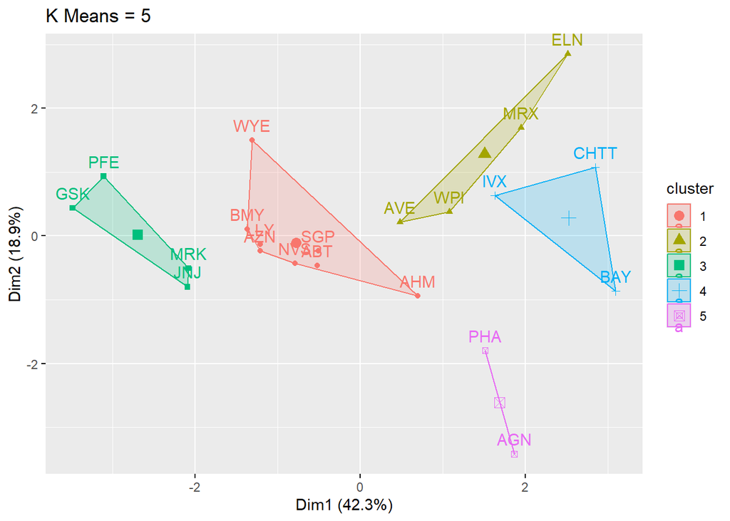

```r
plot_k_pharma_5<-fviz_cluster(kmeans_pharma_5,data = Scaled_pharma) + ggtitle("K Means = 5")
plot_k_pharma_5
```

```r
clustering_run_1<-cluster%>%
  mutate(Cluster_no=kmeans_pharma_5$cluster)%>%
  group_by(Cluster_no)%>%summarise_all('mean')
clustering_run_1
```

```
## # A tibble: 5 × 10
##   Cluster_no Market_Cap  Beta PE_Ratio   ROE   ROA Asset_Turnover Leverage
##        <int>      <dbl> <dbl>    <dbl> <dbl> <dbl>          <dbl>    <dbl>
## 1          1      55.8  0.414     20.3  28.7 12.7           0.738    0.371
## 2          2      13.1  0.598     17.7  14.6  6.2           0.425    0.635
## 3          3     157.   0.48      22.2  44.4 17.7           0.95     0.22
## 4          4       6.64 0.87      24.6  16.5  4.17          0.6      1.65
## 5          5      31.9  0.405     69.5  13.2  5.6           0.75     0.475
## # ℹ 2 more variables: Rev_Growth <dbl>, Net_Profit_Margin <dbl>
```

Companies are grouped into following clusters:

Cluster 1 – The companies are grouped as per moderate-level gains on investment.(WYE, BMY, LLY, AZN, SGP,NVS, ABT, AHM)

Cluster 2 – The companies are grouped with a high level of risk and bad ROI.(ELN, MRX, WPI, AVE)

Cluster 3 – The companies are grouped into which give amazing levels of ROI and which are very profitable.(PFE, GSK, MRK, JNJ)

Cluster 4 - The companies are grouped with an extremely high level of risk and very bad ROI.(CHTT, IVX, BAY)

cluster 5 – These companies have a P/E ratio but the gains do not justify the risk.(PHA, AGN)

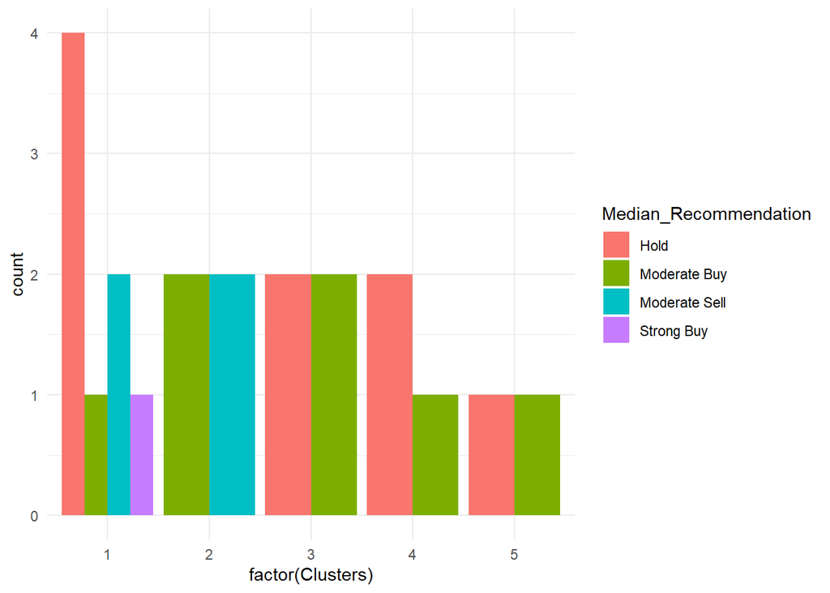

```r
clustering_run_2<- pharma[,12:14] %>% mutate(Clusters=kmeans_pharma_5$cluster)
ggplot(clustering_run_2, mapping = aes(factor(Clusters), fill =Median_Recommendation))+geom_bar(position = "dodge") + theme_minimal()
```

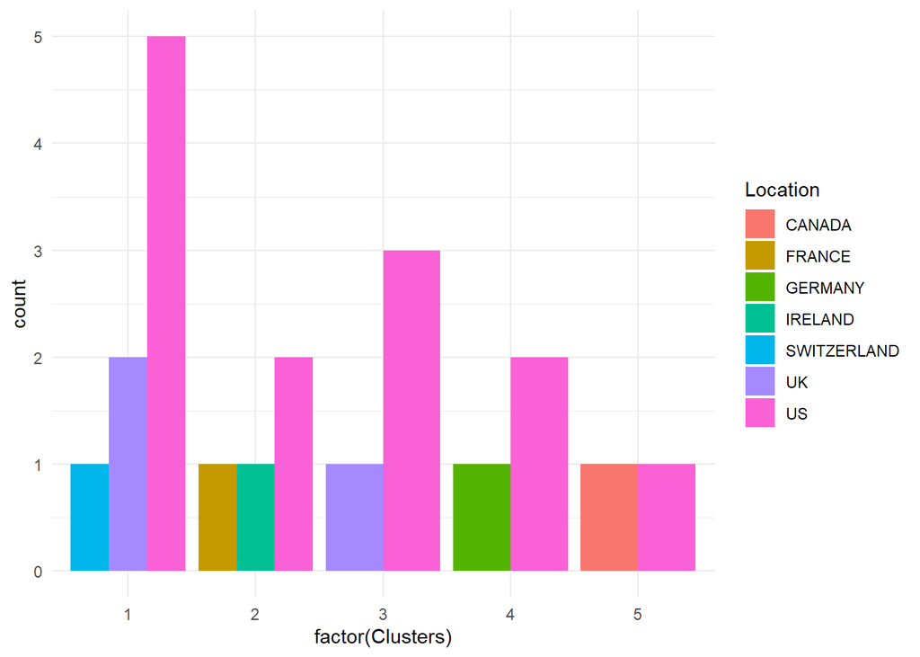

```r
ggplot(clustering_run_2, mapping = aes(factor(Clusters),fill = Location))+geom_bar(position = "dodge") + theme_minimal()
```